# Rendu Travaux Pratiques 5

#### Règles de rendu

- Chaque TP donne lieu à un bref compte-rendu portant sur certaines questions posées dans l’énoncé du TPs.
- Le compte-rendu doit être complété à partir du texte de l’énoncé. Les codes R doivent être inclus dans le texte du compte-rendu (menu **Insert**) et commentés avec précision. **Les commentaires compteront pour une part importante dans la note**.
- Le compte-rendu doit être déposé **sur TEIDE à la date indiquée**. Les rendus en retard seront fortement pénalisés.
- Le compte-rendu doit être déposé **sur TEIDE au format HTML uniquement**. Utiliser la fonction **Preview** ou **knitr** du menu de rstudio pour obtenir le document au format souhaité. **Les fichiers “source” (Rmd) ne seront pas acceptés par les correcteurs**.

Le dépot comportera en plus du fichier intitulé “Rendu_TP5.html”

- un “objet” R sauvé sous forme compressée contenant le modèle choisi pour être évalué par l’enseignant sur l’ensemble test. Le fichier compressé devra être sauvé sous le format RDS ou sous le format hdf5. Son intitulé devra être personnalisé sous la forme “my_login_bestmodel.RDS” ou “my_login_bestmodel.hdf5”.
- Un script R, contenant une fonction permettant d’évaluer le modèle.

## Exercice : Défi analyse d’opinion (IMDB)

#### Analyse d’association

- Dans quelles proportions les termes de valeur d’association $r^2$ supérieure à 0.02 apparaissent-ils dans les documents ? Représenter graphiquement ces proportions à l’aide d’un diagramme en barre.

```r
# chargement des librairies
library(magrittr)
library(keras)
set.seed(seed = 10100101)

# on charge les données (2000 entrées), en filtrant les 48 premieres entrees qui sont les plus fréquents et donc n'aideront pas à décider si la connotation est positive ou négative
imbd <- keras::dataset_imdb(path = "imdb.npz",
                              num_words = 2048,
                              skip_top = 48)

# Le numéro trouvé dans l'index correspond au rang d'un terme donné.
  index <- keras::dataset_imdb_word_index()
# on réordonne les éléments de index selon la fréquence d'apparition du mot
  o <- as.numeric(index) %>% order()

# on convertit le vecteur imbd en une matrice x_imbd de dimensions 10000x2000 (10000 documents, 2000 mots/doc)
x_imbd <- NULL

# construction de l'ensemble d'apprentissage
for (i in 1:10){
    # on récupère des tranches de 500 documents. on effectue le traitement par tranches pour suivre l'avancement (l'opération est assez lente)
    x_imbd_500 <- NULL
      for (j in (500*(i-1)+1):(500*i)){
        # j ème document
        doc_temp <- imbd$train$x[[j]]
        x_imbd_500 <- rbind(x_imbd_500,
                         sapply(49:2048,
                                FUN = function(ind) sum(doc_temp == ind)))
        if (j%%500 == 0) print(j) # ca rassure
      }
    # on ajoute à la fin de x_imbd ce qu'on vient de traiter
    x_imbd <- rbind(x_imbd, x_imbd_500)
  }
```

```
## [1] 500
## [1] 1000
## [1] 1500
## [1] 2000
## [1] 2500
## [1] 3000
## [1] 3500
## [1] 4000
## [1] 4500
## [1] 5000
```

```r
# construction de l'ensemble test, de la même manière que l'ensemble d'apprentissage
 for (i in 1:10){
    x_imbd_500 <- NULL
      for (j in (500*(i-1)+1):(500*i)){
        doc_temp <- imbd$test$x[[j]]
        x_imbd_500 <- rbind(x_imbd_500,
                         sapply(49:2048,
                                FUN = function(ind) sum(doc_temp == ind)))
        if (j%%500 == 0) print(j) # ca rassure
    }
    x_imbd <- rbind(x_imbd, x_imbd_500)
 }
```

```
## [1] 500
## [1] 1000
## [1] 1500
## [1] 2000
## [1] 2500
## [1] 3000
## [1] 3500
## [1] 4000
## [1] 4500
## [1] 5000
```

```r
# on écarte le 2000ème document car la corrélation n'est pas calculable (écart type nul)
  x <- x_imbd[,-2000]
# représentation des classes 0 et 1 en format matriciel
  y_imbd <- to_categorical(imbd$train$y[1:5000], 2)
  y_imbd <- rbind(y_imbd, to_categorical(imbd$test$y[1:5000], 2))

  y <- y_imbd[,1]

# calcul de le coefficient de corrélation au carré entre les fréquences d'apparition des termes de l'index et opinion des utilisateurs
  r2 <- cor(x,y)^2
```

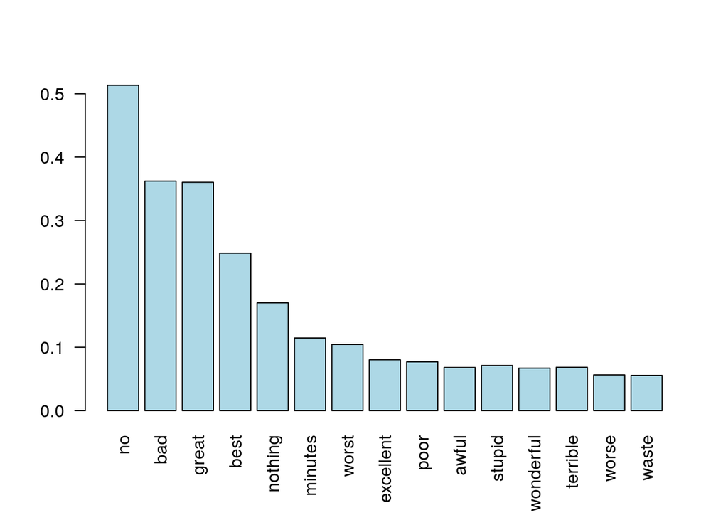

```r
# Calculer la frequence des termes realisant la condition r2>0.02
  freq <- x[, r2 > 0.02] %>% apply(2,mean)
# mots dans l'index et barplot
  names(freq) <-  index[o[which(r2 > 0.02) + 45]] %>% names()
  barplot(freq, col = "lightblue", las = 2)
```

- Dans quelles proportions les termes de valeur d’association $r^2$ supérieure à 0.02 apparaissent-ils dans les documents **à connotation positive** ? Représenter graphiquement ces proportions à l’aide d’un diagramme en barre.

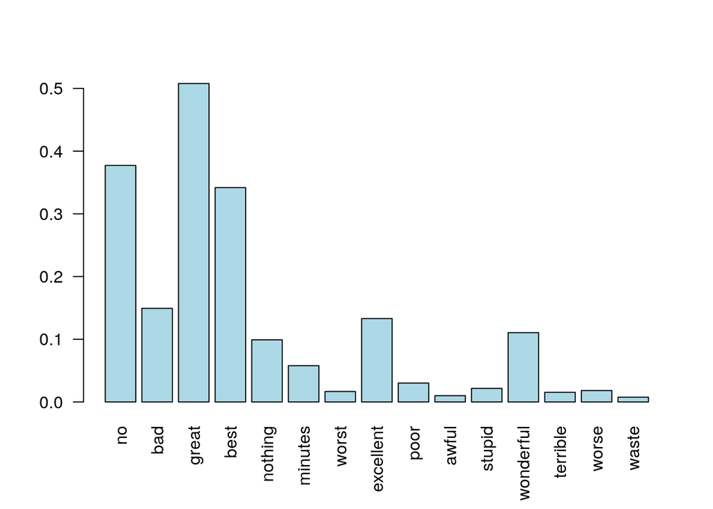

```r
# on rajoute la condition y==0 pour conserver les docs à connotation positive
  freq <- x[y == 0 , r2 > 0.02] %>% apply(2,mean)
  names(freq) <-  index[o[which(r2 > 0.02) + 45]] %>% names()
  barplot(freq, col = "lightblue", las = 2)
```